# GitHub

GitHub is a platform for version control based on Git. Users can host repositories, either public or private, where projects can be developed individually or in teams, with the advantage of versions been tracked, easily restoring to previous points of the project development.

Besides GitHub, Microsoft Azure DevOps and Amazon AWS CodeCommit are common platforms based on Git for version control.

## Step 0 -- Create an Account & Install Git/Github Desktop

Install or update Git. If you do not have Git installed on your PC, you can download it [here](https://git-scm.com/book/en/v2/Getting-Started-Installing-Git). Select the executable file corresponding to your operating system and install Git. Note that the installation requires many choices; just use the pre-selected or recommended ones.

Additionally, install [GitHub Desktop](https://desktop.github.com/).

Go to the [GitHub Homepage](https://github.com/), sign up and follow the steps to activate your account. If you already have a GitHub account you can use it. Simply log in.

## Step 1 -- Create your initial test repository and manage access

To create a repository, go to your Github account, press the **+** on the top right of the page and select *New repository*. Name your test repository as you like and include a description.

Be sure to select the **Private** option, and check the **Add a README file**. You can now create your repository. **Only one student per group should create the repository.**

Since the repo is private, you need to manage its access. Within the Github repo, go to **settings** and select **Manage access**. Press the green button **"Add people"**, and add the Github IDs of all your group members. Even though the repo is private, this allows them to see, edit and manage it. An invitation is sent to each member of the group. One way to accept it is for each member to open the repo on their browsers; the invitation should be there.

## Step 2 -- CMD

The most basic way to interact with a repository is via the command line.

#### Open the Command Prompt/Terminal

Windows:

> WINDOWS + R -> cmd -> Enter <OR> WINDOWS SEARCH "cmd" -> Enter

Mac:

> Launchpad -> type "Terminal" -> Enter

#### Change Directory to where you want to locally store the repo

> cd {YOUR_DESIRED_FOLDER_PATH}

Two important git commands that you can use anytime are simply `git`, to check what git functions you can use, and `git status`, to check the status of your active repo.

## Step 3 -- Clone your created repo

To work on your repo, you should have it loaded on your computer. To do so, input the command below.

> git clone [https://github.com/{USERNAME}/{REPO_NAME}.git](https://github.com/%7BUSERNAME%7D/%7BREPO_NAME%7D.git)

You can copy the repo path by accessing your repo on GitHub website and pressing on the green button named "code". There, copy the HTTPS link. The command prompt will display such a message:

```
cmd
Cloning into 'test_repo1'...
remote: Enumerating objects: 3, done.
remote: Counting objects: 100% (3/3), done.
remote: Total 3 (delta 0), reused 0 (delta 0), pack-reused 0
Receiving objects: 100% (3/3), done.
```

Your repo has been cloned into your machine and you can now work on your project. Add or change files as much as needed. This procedure is exactly the same for every member of the group, you can all clone the repo and work independently on it.

After adding some files, you can proceed to the next stage: commiting your changes.

Do not forget to change the command prompt directory into the repository: `cd {REPO_NAME}`.

## Step 4 -- Adding changes to be committed

Commiting your local changes simple prepares them to be uploaded into your repo. You can check the changes that have been done using.

> git status

Returing something like

```
cmd
On branch main
Your branch is up to date with 'origin/main'.

Changes not staged for commit:
  (use "git add <file>..." to update what will be committed)
  (use "git restore <file>..." to discard changes in working directory)
        modified:   README.md

Untracked files:
  (use "git add <file>..." to include in what will be committed)
        text_file1.txt

no changes added to commit (use "git add" and/or "git commit -a")
```

As you can see, the command mentions that one file was modified (README.md) and one new file was added (text_file1.txt).

**INITIALLY, TO AVOID CONFLICTS, CHOOSE ONLY ONE GROUP MEMBER TO COMMIT THE CHANGES. THIS REGARDS STEPS 4 AND 5.**

To commit changes to your repo, you need to had the chenges, then commit them, and finally push them to the online repo. The next to lines show how you can add all modifications or a single new (or modified) file.

- To add all new and modified files

> git add -A
- To add a specific file (text_file1.txt in this example)

> git add text_file1.txt

Checking again the git status after adding all files, the command prompt returns

```
cmd
On branch main
Your branch is up to date with 'origin/main'.

Changes to be committed:
  (use "git restore --staged <file>..." to unstage)
        modified:   README.md
        new file:   text_file1.txt
```

## Step 5 -- Committing the added files & pushing them to the repo

To commit the files previously added, simply enter the command

> git commit -m "added text_file1.txt and modified readme"

The text inside quotes is the description of the commit. It is important to accurate and consisely describe the modifications in order for the users to keep track of the versions. Cmd returns the following:

```
cmd
[main 936d1e9] added text_file1.txt and modified readme
 2 files changed, 6 insertions(+)
 create mode 100644 text_file1.txt
```

The `git status` command shows the following

```
cmd
On branch main
Your branch is ahead of 'origin/main' by 1 commit.
  (use "git push" to publish your local commits)

nothing to commit, working tree clean
```

The status acknowledges that while there is nothing to commit, the local branch is ahead by one commit, meaning that the repo is lacking the commit that was made. This requires one final step:

> git push

```
cmd
Enumerating objects: 6, done.
Counting objects: 100% (6/6), done.
Delta compression using up to 8 threads
Compressing objects: 100% (3/3), done.
Writing objects: 100% (4/4), 446 bytes | 446.00 KiB/s, done.
Total 4 (delta 0), reused 0 (delta 0), pack-reused 0
To https://github.com/USER/test_repo1
   3585c08..936d1e9  main -> main
```

This step publishes the commit. If you refresh the github repo webpage, you can see that the readme file has been modified and that the text file has been added.

## Step 6 -- Pulling the repo

If many people are working on the same repo, as is the case for this example, it will rarely be static. To avoid clashes between modifications made by different users, you should pull the latest version of the repo before commiting. If no chanegs were verified, or if the changes do not directly affect your own, you are free to commit. To pull the latest version of the repo, simply type

> git pull

If no commits have been made, the command prompt will simply display

```
cmd
Already up to date.
```

Otherwise, the files pulled from the repo are printed on the command prompt.

Perform a `git pull` to receive the changes pushed from the previous stages.

## Step 7 -- Managing clashes

Consider two users of the same repo. User 1 changes the document `text_file1.txt` to:

```
cmd
This is an example of a text file.

- Line 1 contains this item
- Line 2 contains this other item

This is the end of the file
```

The user then follows the aforementioned steps: `git pull`, `git add -A`, `git commit -m "changes to text_file1.txt"`, `git push`.

At the same time, user 2 changes document `text_file1.txt` to:

```
cmd
This is an example of a text file.

-> This line is slightly different
o This other line is even more different

This is the end of the file
```

To commit the changes first do a `git pull`. The cmd will identify an error and suggest committing the changes first. `git add -A`, then `git commit -m "changes to text_file1.txt no2"`. If you try to `git push`, the cmd will return:

```
cmd
To https://github.com/USER/test_repo1
 ! [rejected]        main -> main (non-fast-forward)
error: failed to push some refs to 'https://github.com/USER/test_repo1'
hint: Updates were rejected because the tip of your current branch is behind
hint: its remote counterpart. Integrate the remote changes (e.g.
hint: 'git pull ...') before pushing again.
hint: See the 'Note about fast-forwards' in 'git push --help' for details.
```

This means that a clash has been identified: **both users committed changes to the same file**. To analyze the clashes, simply `git pull`. Cmd will say that the conflict was merged in the file, meaning that it is up to you to decide what to store and what to remove. The text file is formated in such a way:

```
cmd
This is an example of a text file.

<<<<<<< HEAD
-> This line is slightly different
o This other line is even more different
=======
- Line 1 contains this item
- Line 2 contains this other item
>>>>>>> eb779885a53e4f29ef0c178e1c25692169fcd11e

This is the end of the file
```

Simply correct the file as you see fit, then `git add -A`, `git commit -m "fixed commit conflicts on text_file1.txt"`, `git push`.

**Now it is your turn to manage clashes. Working independtly, change your repo as you see fit, both adding new files and/or changing existing ones. Then follow the regular commit steps. If the `git push` is successful, than no conflict has been detected, and you have either been the first to commit, or your changes did not affect your colleagues'. Otherwise, manage the changes as detailed above.**

## Step 8 -- Branch & Merge

The final concept that you should practice is the concept of branches. Consider the practical application of a repo of an application. The application is live and working perfectly, but there are updates that you wish to implement. The best way to make this changes is to branch the main repo into a development branch, so that you can work safely and without affect the working main branch.

To test this, one member of the group should create a branch. First type into cmd `git checkout -b BRANCH_NAME`. Use 'devel' as the branch name. Cmd will return

```
cmd
Switched to a new branch 'devel'
```

Then, push the origin to the created branch. Type `git push origin devel` in cmd.

```
cmd
Total 0 (delta 0), reused 0 (delta 0), pack-reused 0
remote:
remote: Create a pull request for 'devel' on GitHub by visiting:
remote:      https://github.com/USER/test_repo1/pull/new/devel
remote:
To https://github.com/USER/test_repo1
 * [new branch]      devel -> devel
```

You can now do a `git pull` on each member's computer, and you will see that cmd says that a new branch was created. You can check your branches with `git branch -a`:

```
cmd
* devel
  main
  remotes/origin/HEAD -> origin/main
  remotes/origin/devel
  remotes/origin/main
```

The asterisk indicates which branch is active. On a different computer (after having pulling the repo), the "devel" will appear on the list (a line showing `remotes/origin/devel`), but the devel branch will not be shown on the two upper branches. Similarly, if you only type `git branch`, there will be no mention to the devel branch. This is because the branch was never activated locally. Simply type `git checkout devel` to change to the devel branch.

You can now add your own changes on the devel branch (make sure you are selecting that branch, checking with `git branch` and changing with `git checkout devel`).

After the development of the "devel" branch has been completed and is working properly, you can merge it to the main branch, for it to become the new version of your repo. To do this, start by changing to the main branch (`git checkout main`). Then enter the command `git pull origin main` which will pull changes from the origin remote - main branch and merge them to the local checked-out branch; in another words it will simply pull the changes applied to the main branche into the main branch. While redundant, this should remove any conflits to the main branch. Cmd will return the following

```
cmd
From https://github.com/USER/test_repo1
 * branch            main       -> FETCH_HEAD
Already up to date.
```

After doing this, simply type `git merge devel`, which will merge the devel branch into the activated branch, *i.e.* the main branch. Cmd will return

```
cmd
Updating d9cd666..0ff85a4
Fast-forward
 text_file4.txt | 1 +
 text_file5.txt | 1 +
 2 files changed, 2 insertions(+)
 create mode 100644 text_file4.txt
 create mode 100644 text_file5.txt
```

Finally, type `git push origin main`, which similarly to `git pull origin main`, will push the current branch (main) into the main branch. Cmd will return

```
cmd
Total 0 (delta 0), reused 0 (delta 0), pack-reused 0
To https://github.com/jmsantos12/test_repo1
   d9cd666..0ff85a4  main -> main
```

## Step 8.1 -- User branches

A common practice that you can adopt for your projects is to have a specific development branch for each group member. This way, you will avoid many conflicts, only when changes are merged into the main branch. The pipeline would be to frequently merge the members' branches into the main, to have as up-to-date as possible, will having the least amount of conflicts possible.

# GitHub Desktop

Git commands executed from the command line are very useful to learn the bases however there are user interfaces to work on repositories.

[GitHub Desktop](https://desktop.github.com/) is one of those that simplify your git development workflow.

Analogously, the steps in the previous section can be performed in Github Desktop. (Note: Unmentioned steps are not necessary)

## Step 0 -- Launch GitHub Desktop

- Launch GitHub Desktop app
- Go to `File -> Options` and ensure your GitHub account is setup.

[figure not shown]

## Step 1 -- Clone your created repo

- Clone the previous created repository `File -> Clone repository...`
- Insert **url** or detail repository in the form of **username/repository**

[figure not shown]

## Step 2 -- Adding changes to be committed

- Make a change in a file of your repository
- At left, you can see in `Changes` the last changes that you made to your repository. In green appears what you added and in red what you removed.
- On the same tab, you have `History` which contains all your commits

[figure not shown]

## Step 3 -- Committing the added files & pushing them to the repo

- In lower left corner, you can commit your changes giving a name to your commit
- Example `Create new text_file1.txt`

[figure not shown]

- Then in the top, press `Push origin`to publish your commit

[figure not shown]

## Step 3 -- Pulling the repo

- In the same place where you pushed your commit, you can pull if another user has made commits by `Pull origin`
- You should often `Fetch origin` to make sure you are up to date in your repository.

[figure not shown]

## Step 4 -- Branch & Merge

- To create a new branch, you should open `Current branch` tab and simple create a `New branch` with the name you desire.

[figure not shown]

- To merge a branch, in the bottom of the same tab you can `Choose a branch to merge into your 'branch'`

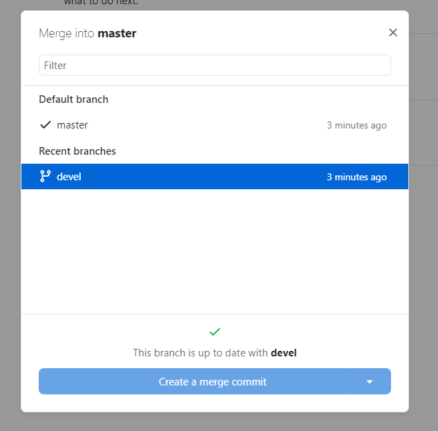

## Step 5 -- Managing Clashes

- If there are changes in the same file when merging branches, a warning will appear.

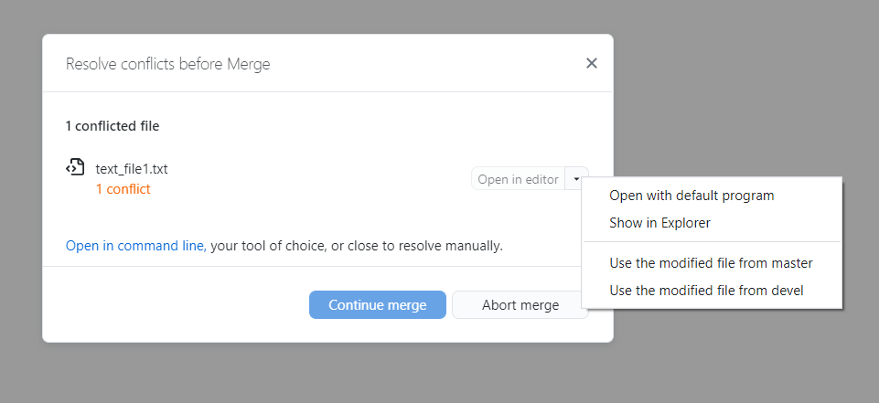

- You can choose between each branch do you want the changes or open an editor to choose independetly each change

For a more detailed approach explore the following page: [Github Desktop Tutorial](https://docs.github.com/pt/desktop/installing-and-configuring-github-desktop/overview/getting-started-with-github-desktop)

# Step Extra — Access to Course GitHub

After signing up for a group in Fenix, you should fill in the Excel sheet [Course GitHub](https://docs.google.com/spreadsheets/d/1KjAHmivHbrvMa52OmY2r2_CJOLc85R0HdnRCzOFo0aU/edit?usp=sharing) with your **GitHub username**.

Later, an email invitation will be sent. By accepting it, you will be added to your group repository.

This repository contains the base structure for the project and assignments. All folders are described in the README file.

There is also a folder to save your files from the laboratory classes.

It is desirable that the groups in the laboratory are the same as in the final project.